# Visualizing co-occurrences of diagnoses in a patient dataset to see patterns by means of Upset Plots

Adeline Makoudjou

12/29/2022

## Problem statement

Contingency tables are in general used to evaluate or cross the simultaneous combination of many characteristics in data. While crossing two qualitative variables might be quite easy to visualize in tables, beyond three variables the task appears to be quite confusing. However in medical analyses, especially for diagnoses, it might be quite helpful to investigate in patients the co-occurrence of medical diagnoses in order to reveal clinical patterns and orientate the decision making. Upset plots turn out to be an ideal tool to visualize and investigate the combination of many diagnoses as well as symptoms in clinical patients. In the framework of this demonstration I will visualize the co-occurrence of diagnoses in patients as well as investigating some of the characteristics of the patients in each combination of diagnoses.

**INPUT:** an open source patient dataset file in csv format **nhefs.csv** made available by the University of Havard

A code book of the variables in the dataset is also provided in the file entitled **NHEFS_Codebook.csv**

**OUTPUT:** a PDF file, displaying the UpSet Plot of the combinations of most frequent diagnoses, annotated by other characteristics to show patterns

## Dataset description

For the purpose of this project, I will use the **nhefs dataset** which is a cleaned data set of the data used in Causal Inference by Hernán and Robins. nhefs is dataset containing data from the National Health and Nutrition Examination Survey Data I Epidemiologic Follow-up Study (NHEFS). The NHEFS was jointly initiated by the National Center for Health Statistics and the National Institute on Aging in collaboration with other agencies of the United States Public Health Service. A detailed description of the NHEFS, together with publicly available data sets and documentation, can be found at https://www.hsph.harvard.edu/miguel-hernan/causal-inference-book/

## Loading libraries and dataset

```r
####################################################
############## R options & libraries ###############
####################################################

options(stringsAsFactors=FALSE)


if(!require("ComplexUpset"))
{
    install_github("https://github.com/cran/ComplexUpset")
}



if(!require("naniar"))
{
    install_github("https://github.com/cran/naniar")
}

if(!require("ggplot2"))
{
    install_github("https://github.com/cran/ggplot2â")
}

if(!require("patchwork"))
{
    install_github("https://github.com/thomasp85/patchwork")
}

library(devtools)
## Loading required package: usethis
library(ComplexUpset)   # to make the Upset Plot
library(ggplot2)        # to decorate the Upset Plot
library(patchwork)      # to produce the final plot
library(lubridate)    # for date functions
library(dplyr)
library(naniar)
```

```r
file="nhefs.csv"
data=read.csv(file, colClasses="character")

# Displaying the names of the variables in the dataset
colnames(data)
```

```
##  [1] "seqn"              "qsmk"              "death"
##  [4] "yrdth"             "modth"             "dadth"
##  [7] "sbp"               "dbp"               "sex"
## [10] "age"               "race"              "income"
## [13] "marital"           "school"            "education"
## [16] "ht"                "wt71"              "wt82"
## [19] "wt82_71"           "birthplace"        "smokeintensity"
## [22] "smkintensity82_71" "smokeyrs"          "asthma"
## [25] "bronch"            "tb"                "hf"
## [28] "hbp"               "pepticulcer"       "colitis"
## [31] "hepatitis"         "chroniccough"      "hayfever"
## [34] "diabetes"          "polio"             "tumor"
## [37] "nervousbreak"      "alcoholpy"         "alcoholfreq"
## [40] "alcoholtype"       "alcoholhowmuch"    "pica"
## [43] "headache"          "otherpain"         "weakheart"
## [46] "allergies"         "nerves"            "lackpep"
## [49] "hbpmed"            "boweltrouble"      "wtloss"
## [52] "infection"         "active"            "exercise"
## [55] "birthcontrol"      "pregnancies"       "cholesterol"
## [58] "hightax82"         "price71"           "price82"
## [61] "tax71"             "tax82"             "price71_82"
## [64] "tax71_82"
```

## Data exploration and visualization of some characteristics

```r
head(data, n=2)
```

```
##   seqn qsmk death yrdth modth dadth sbp dbp sex age race income marital school
## 1  233    0     0                   175  96   0  42    1     19       2      7
## 2  235    0     0                   123  80   0  36    0     18       2      9
##   education       ht  wt71        wt82      wt82_71 birthplace smokeintensity
## 1         1 174.1875 79.04 68.94604024 -10.09395976         47             30
## 2         2  159.375 58.63 61.23496995   2.60496995         42             20
##   smkintensity82_71 smokeyrs asthma bronch tb hf hbp pepticulcer colitis
## 1               -10       29      0      0  0  0   1           1       0
## 2               -10       24      0      0  0  0   0           0       0
##   hepatitis chroniccough hayfever diabetes polio tumor nervousbreak alcoholpy
## 1         0            0        0        1     0     0            0         1
## 2         0            0        0        0     0     0            0         1
##   alcoholfreq alcoholtype alcoholhowmuch pica headache otherpain weakheart
## 1           1           3              7    0        1         0         0
## 2           0           1              4    0        1         0         0
##   allergies nerves lackpep hbpmed boweltrouble wtloss infection active exercise
## 1         0      0       0      1            0      0         0      0        2
## 2         0      0       0      0            0      0         1      0        0
##   birthcontrol pregnancies cholesterol hightax82      price71      price82
## 1            2                     197         0   2.18359375 1.7399902344
## 2            2                     301         0 2.3466796875 1.7973632813
##          tax71        tax82   price71_82     tax71_82
## 1 1.1022949219 0.4619750977 0.4437866211 0.6403808594
## 2 1.3649902344 0.5718994141 0.5493164063   0.79296875
```

```r
diseases <- c( "asthma", "bronch", "tb","hf","hbp", "pepticulcer","colitis","hepatitis","chroniccough","hayfever", "diabetes", "polio",  "tumor", "nervousbreak")

# since we are just interested in diseases, I subselect the corresponding variables with other additional features in a new data frame
subdata <- data[, c(diseases, "death", "smokeyrs", "sex","age", "alcoholfreq","education", "race", "exercise")]

# investigating the presence of missing data
colSums(is.na (subdata))
```

```
##       asthma       bronch           tb           hf          hbp  pepticulcer
##            0            0            0            0            0            0
##      colitis    hepatitis chroniccough     hayfever     diabetes        polio
##            0            0            0            0            0            0
##        tumor nervousbreak        death     smokeyrs          sex          age
##            0            0            0            0            0            0
##  alcoholfreq    education         race     exercise
##            0            0            0            0
```

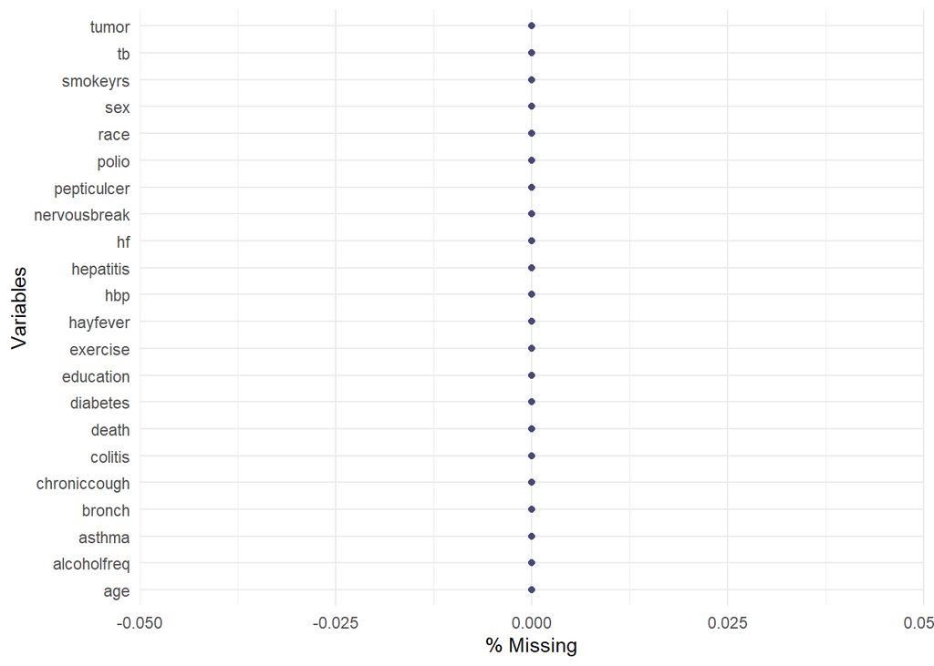

```r
## Forcing conversion of some numerical variables loaded as strings

subdata[c(diseases,"smokeyrs","age")] <- lapply(subdata[c(diseases,"smokeyrs","age")],as.numeric)





gg_miss_var(subdata,show_pct = TRUE)
```

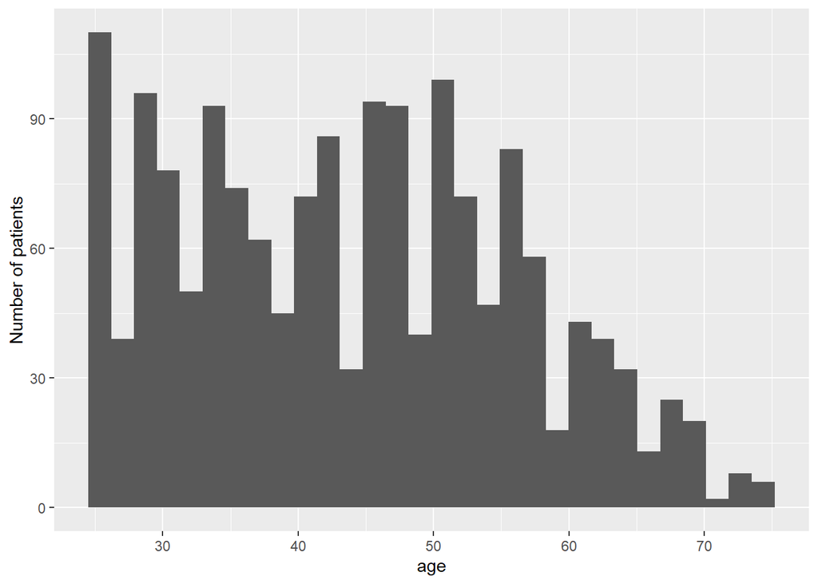

```r
par (mfrow=(c(2,2)))

## Age distribution in the dataset

ggplot(subdata, aes(x=age)) +
  geom_histogram()+
  ylab("Number of patients")
```

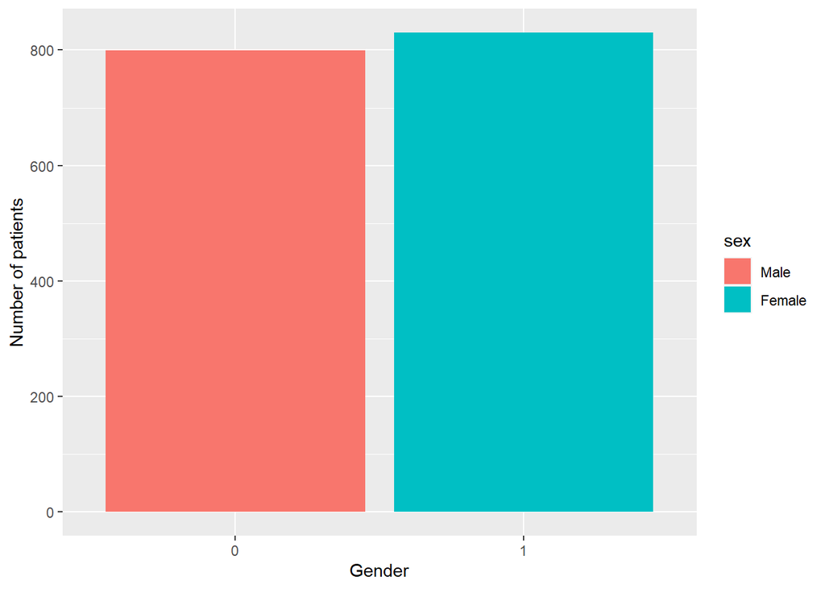

```r
ggplot(subdata, aes(x=sex, fill=sex)) +
  geom_bar() +
  scale_fill_discrete(labels=c("Male", "Female"))+
  xlab("Gender")+
  ylab("Number of patients")
```

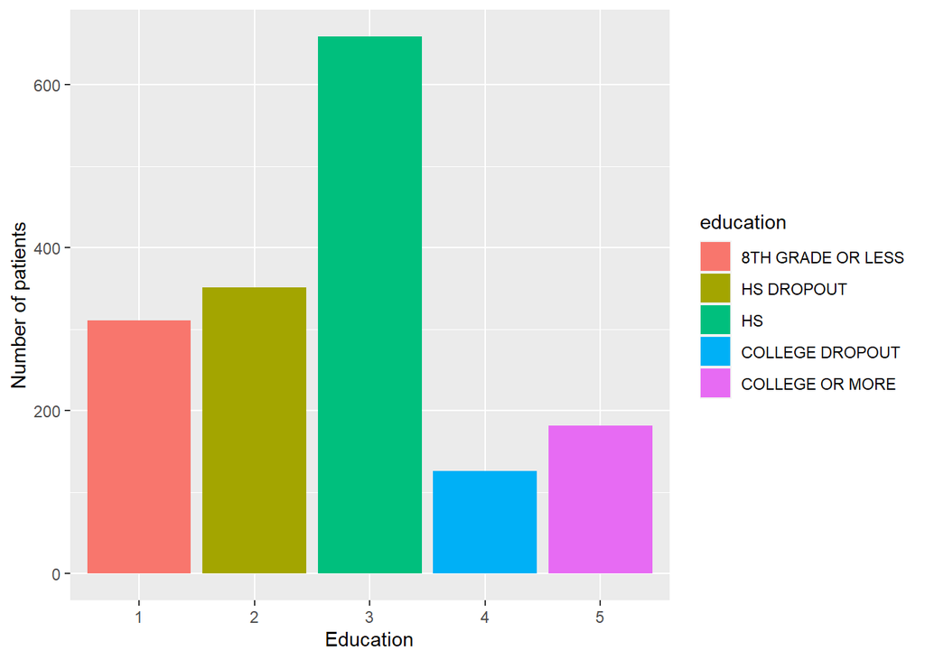

```r
# 1: 8TH GRADE OR LESS, 2: HS DROPOUT, 3: HS, 4:COLLEGE DROPOUT, 5: COLLEGE OR MORE
ggplot(subdata, aes(x=education, fill=education)) +
  geom_bar() +
  scale_fill_discrete(labels=c("8TH GRADE OR LESS", "HS DROPOUT", "HS", "COLLEGE DROPOUT","COLLEGE OR MORE"))+
  xlab("Education")+
  ylab("Number of patients")
```

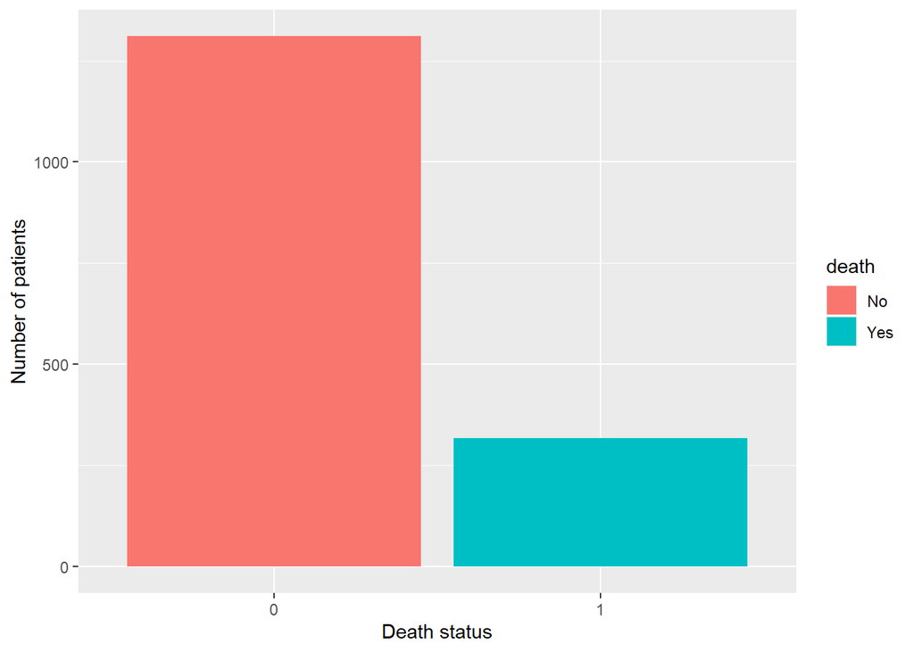

```r
ggplot(subdata, aes(x=death, fill=death)) +
  geom_bar() +
  scale_fill_discrete(labels=c("No", "Yes")) +
  xlab("Death status")+
  ylab("Number of patients")
```